# Understanding Chance

Lecture 0 - FNDN07018

# Randomness

## Events

When we say an event happens **randomly**, what does that mean?

Examples of **events**:

1. You roll a six with a die.
2. You roll two sixes with a pair of dice.
3. A medical test gives a positive result.
4. A filter labels an email as ‘spam’.
5. More than 20cm of snow falls in Edinburgh in a single day.

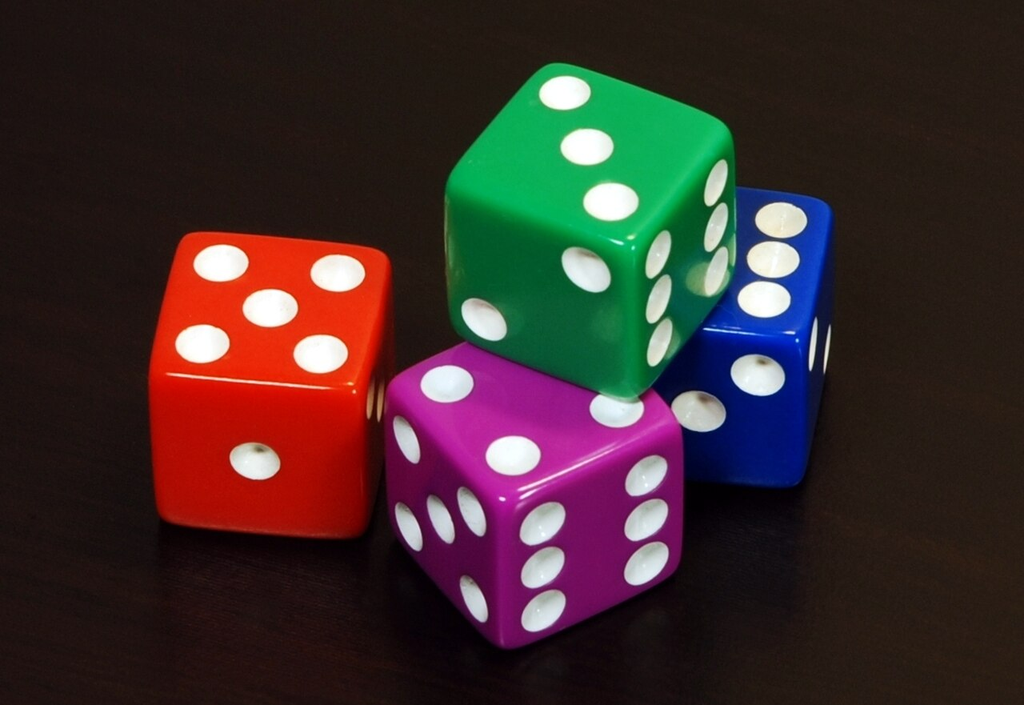

Six-sided dice are commonly just called die.

Let $A$ be an event. The **probability** of $A$ happening is denoted $\mathbb{P}(A)$.

## Experiments

Experiments have a **sample space** (denote $\Omega$) of possible outcomes.

| Experiment | $\Omega$ (Sample Space) |
| --- | --- |
| Roll a dice | $\lbrace 1,2,3,4,5,6 \rbrace$ |
| Roll two dice | $\lbrace (1,1), (1,2), (1,3), \ldots, (1,6), (2,1), \ldots (6,6)\rbrace$ |
| Medical test | $\lbrace\!$ Positive, Negative $\!\rbrace$ |
| Toss a coin | $\lbrace \text{H}, \text{T} \rbrace$ |
| Toss a coin until heads | $\lbrace \text{H}, \text{TH}, \text{TTH}, \text{TTTH}, \ldots \rbrace$ |
| Human lifetime | $0 \leq t < \infty$ |

We refer to events found in a sample space as **elementary events**.

## Probability

Events can be more than elementary! A **non-elementary event** could be $A =$ “roll even”.

| Experiment | $\Omega$ (Sample Space) |
| --- | --- |
| Roll a dice | $\lbrace 1,2,3,4,5,6 \rbrace$ |

If $A$ is the event we are interested in, we can calculate the **probability** of $A$ happening by

$$\mathbb{P}(A) = \frac{\text{# outcomes where $A$ occurs}}{\text{# outcomes in the sample space}}$$

For example, if $X$ is outcome on a die,

- $\mathbb{P}(X=3) = \frac{1}{6}$ $\approx 0.167$,
- $\mathbb{P}(X \in\lbrace 2,4,6 \rbrace) = \frac{3}{6}$ $= 0.5$,
- $\mathbb{P}(X < 3) = \frac{2}{6}$ $\approx 0.333$,
- $\mathbb{P}(X \geq 7) = \frac{0}{6}$ $= 0$.

## Certainty

We often wish to know the **certainty** that an event occurs. We quantify this as **chance**.

Most of us are not very consistent at quantifying how certain we are about something.

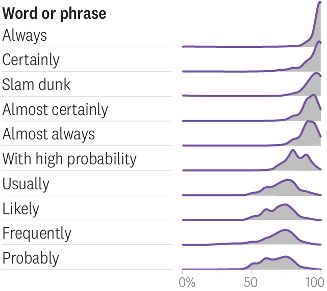

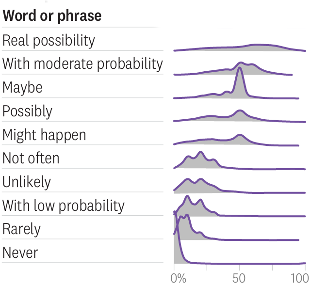

Figure 1: Distribution of responses according to respondents’ estimate of likelihood. See [probabilitysurvey.com](https://www.probabilitysurvey.com/)

# Venn Diagrams

## Idea

If we more than one event ($A$ and $B$ say), it’s useful to have a way to visualise what outcomes in $\Omega$ relate to what event. We can do this with **Venn diagrams**.

[figure not shown]

People go to the website because they can’t wait for the next alumni magazine, right? Source: xkcd.com/773

## Union

The union $A\cup B$ is the combination of both, *i.e.* outcomes in at least one of $A$ **or** $B$.

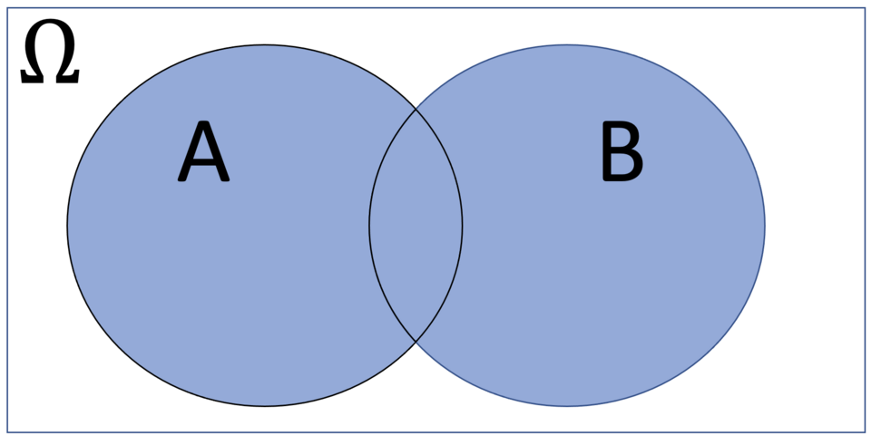

For example, if $A$ is ‘roll even’ and if ‘$B$ is ’roll greater than 3’, then $A \cup B = \lbrace 2, 4, 5, 6\rbrace$.

## Intersection

The intersection $A \cap B$ is the overlap of both, *i.e.* outcomes in both $A$ **and** $B$.

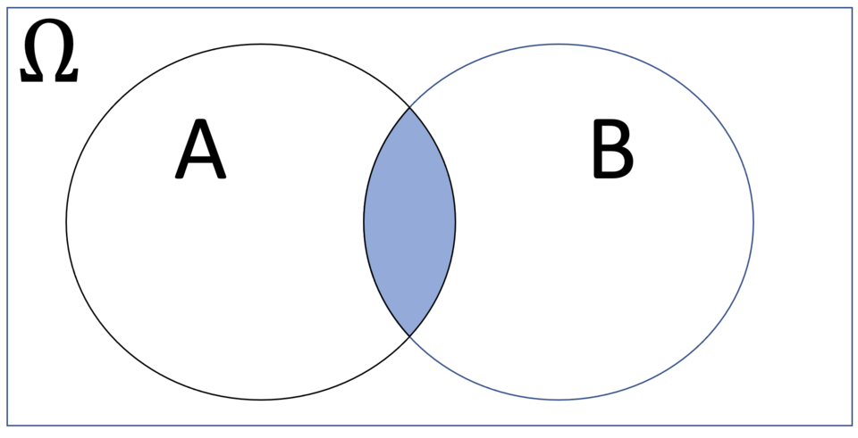

For example, if $A$ is ‘roll even’ and if ‘$B$ is ’roll greater than 3’, then $A \cap B = \lbrace 4, 6\rbrace$.

## Difference

The difference $A\backslash{}B$ are the outcomes in $A$ but **not** in $B$.

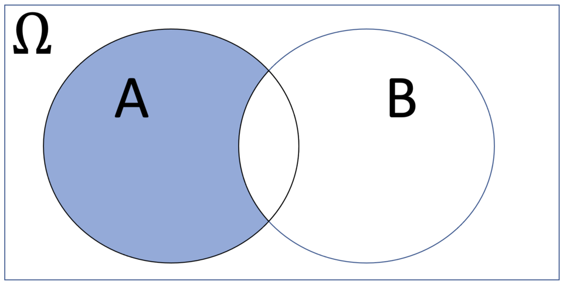

For example, if $A$ is ‘roll even’ and if ‘$B$ is ’roll greater than 3’, then $A \backslash{} B = \lbrace 2 \rbrace$.

## Compliment

The **complement** $A^{\text{C}}$ (also denoted $A^∗$, or $\bar{A}$) is all the outcomes not in $A$, *i.e.* $\Omega\backslash A$.

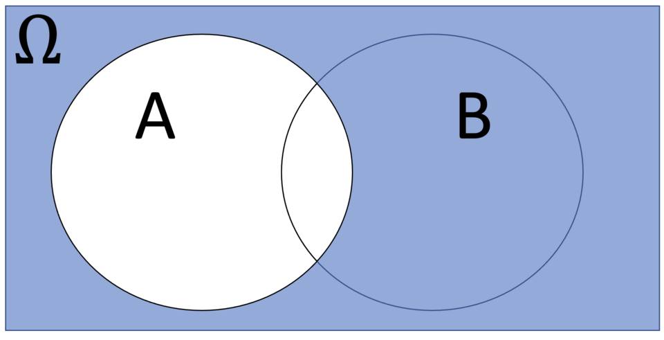

For example, if $A$ is ‘rolls a 3’, $A = \lbrace 3\rbrace$. The compliment of $A$ would be

$$A^{\text{C}} = \Omega\backslash\lbrace3\rbrace = \lbrace 1,2,4,5,6 \rbrace.$$

## Exclusive

Two events $A$ and $B$ are **mutually exclusive** if they have no overlapping outcomes.

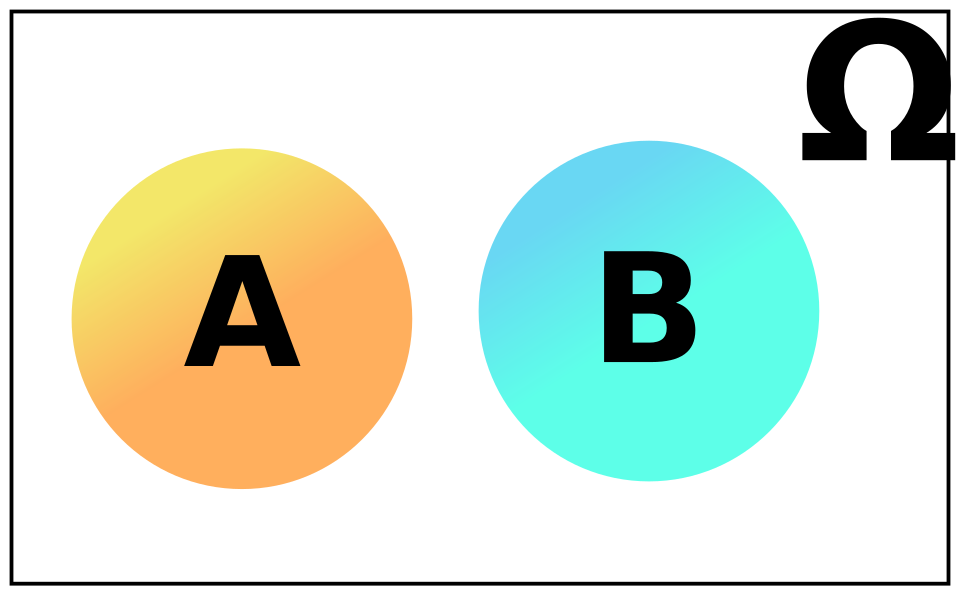

For example, if $A = \lbrace 1,3,5 \rbrace$ (‘roll odd’) and $B = \lbrace 2,4,6 \rbrace$ (‘roll even’).

# Probability Rules

## Axioms

We are now ready to give a definition of the probability $\mathbb{P}(A)$, and to derive some rules.

These are known as **Kolmogorov’s axioms**.

If $\mathbb{P}$ measures probability, with $A$ and $B$ denoting events in $\Omega$, then:

1. $0 \leq \mathbb{P}(A) \leq 1$ for all events $A$ in $\Omega$;
2. $\mathbb{P}(\Omega) = 1$;
3. If $A \cap B = \emptyset$ then<sup>1</sup>
   $$\mathbb{P}(A \cup B) = \mathbb{P}(A) + \mathbb{P}(B).$$

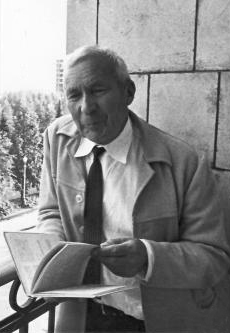

Andrej Kolmogorov

[^1]: ‘$\emptyset=\lbrace\rbrace$’ is the **empty set**.

## Inclusion-Exclusion

We can use Venn diagrams to build an intuition for how probabilities are calculated.

**Question:** if we know the three probabilities,

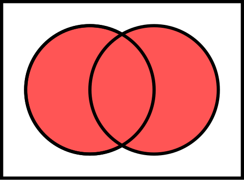

$\color{red}{\mathbb{P}(A \cup B)}$

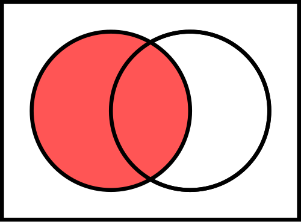

$\color{red}{\mathbb{P}(A)}$

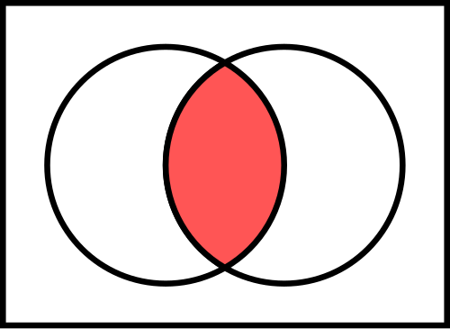

$\color{red}{\mathbb{P}(A \cap B)}$

then what is is $\mathbb{P}(B)$?

**Answer:**

$$\mathbb{P}(B) = \mathbb{P}(A \cup B) - \mathbb{P}(A) + \mathbb{P}(A \cap B).$$

## Example

Two medical conditions are **comorbid** if they occur at the same time as each other.

Surveys have estimated that 7% of children have asthma, 30% have eczema, and for 2% of children the conditions are comorbid.

What is the probability a child has either condition?

**Hint**

1. If $\mathbb{P}(A) = 0.07$, $\mathbb{P}(E) = 0.3$, and $\mathbb{P}(A \cap E) = 0.02$, then what is $\mathbb{P}(A \cup B)$?
2. Remember, $\mathbb{P}(A \cup B) = \mathbb{P}(A) + \mathbb{P}(B) - \mathbb{P}(A \cap B)$.

**Solution:** 35% of children have asthma or eczema, since

$$\mathbb{P}(A \cup B) = \mathbb{P}(A) + \mathbb{P}(B) - \mathbb{P}(A \cap B) = 0.07 + 0.3 - 0.02 = 0.35$$

[figure not shown]